# Homework_07

Shelby N. Scarfo

2024-02-28

I am using a bottom trawling dataset that looks at the catch per unit effort (CPUE) of alewife throughout the three different portions (north, central, south) of the main lake in Lake Champlain. I am not expecting to see any significant differences in CPUE between these regions because they are all part of the main lake and are not geographically isolated from eachother.

### Running ANOVA and Tukey tests on my own data

```r
#Libraries
library(ggplot2)
library(MASS)
library(dplyr)
library(truncnorm)
```

```r
#Loading in data and getting attributes

ALW_CPUE_basin <- read.csv("ALW_CPUE_basin.csv")

ALW_CPUE_basin$minor_basin <- factor(ALW_CPUE_basin$minor_basin, levels = c("North Main Lake", "Central Main Lake", "South Main Lake"))

str(ALW_CPUE_basin)
```

```
## 'data.frame':    345 obs. of  3 variables:
##  $ sampleID   : chr  "BOT_04132018_01" "BOT_04132018_02" "BOT_04132018_03" "BOT_04132018_04" ...
##  $ minor_basin: Factor w/ 3 levels "North Main Lake",..: 2 2 2 2 2 2 2 2 2 2 ...
##  $ CPUE       : num  8.528 37.5 68.903 255.989 0.667 ...
```

```r
summary(ALW_CPUE_basin)
```

```
##    sampleID                    minor_basin       CPUE
##  Length:345         North Main Lake  : 72   Min.   :   0.500
##  Class :character   Central Main Lake:218   1st Qu.:   4.003
##  Mode  :character   South Main Lake  : 55   Median :  20.020
##                                             Mean   :  86.624
##                                             3rd Qu.:  90.337
##                                             Max.   :1404.000
```

```r
ALW_CPUE <- group_by(ALW_CPUE_basin, minor_basin) %>%
  summarise(
    count = n(),
    mean = mean(CPUE, na.rm = TRUE),
    sd = sd(CPUE, na.rm = TRUE)
  )
print(ALW_CPUE) # This shows the sample sizes, means, and variances for each group
```

```
## # A tibble: 3 × 4
##   minor_basin       count  mean    sd
##   <fct>             <int> <dbl> <dbl>
## 1 North Main Lake      72 100.   200.
## 2 Central Main Lake   218  90.1  170.
## 3 South Main Lake      55  55.0  119.
```

```r
#Running ANOVA on data and creating figure

res.aov <- aov(CPUE~minor_basin, data = ALW_CPUE_basin)
summary(res.aov)
```

```
##              Df  Sum Sq Mean Sq F value Pr(>F)
## minor_basin   2   71360   35680   1.239  0.291
## Residuals   342 9851925   28807
```

```r
TukeyHSD(res.aov)
```

```
##   Tukey multiple comparisons of means
##     95% family-wise confidence level
##
## Fit: aov(formula = CPUE ~ minor_basin, data = ALW_CPUE_basin)
##
## $minor_basin
##                                        diff        lwr      upr     p adj
## Central Main Lake-North Main Lake -10.27977  -64.58625 44.02672 0.8963867
## South Main Lake-North Main Lake   -45.40800 -116.95666 26.14065 0.2950901
## South Main Lake-Central Main Lake -35.12824  -95.41458 25.15810 0.3569643
```

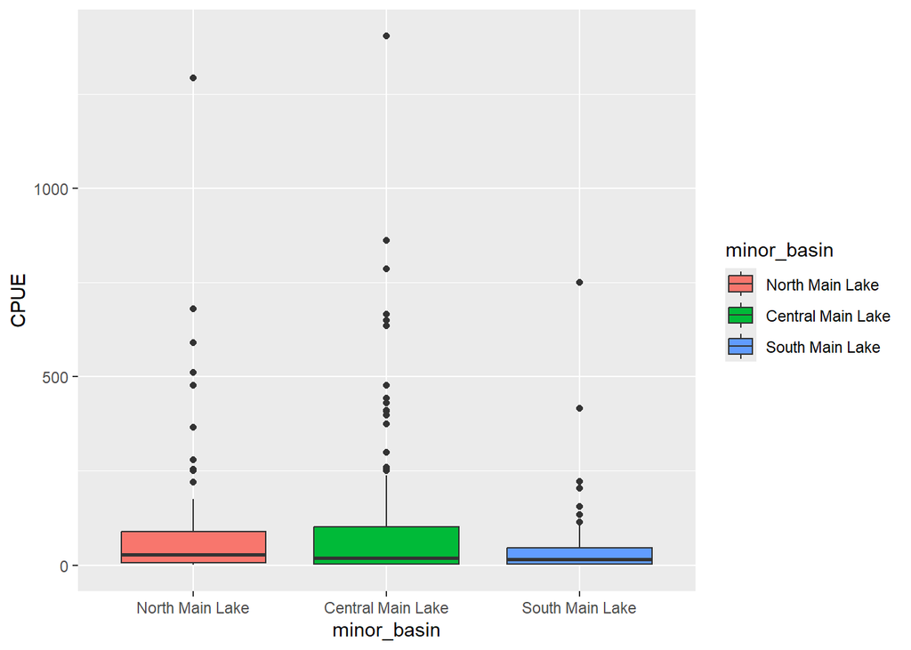

```r
ANOplot <- ggplot(data = ALW_CPUE_basin)+
  aes(x= minor_basin, y = CPUE, fill = minor_basin) +
  geom_boxplot()
ANOplot
```

The ANOVA and tukey tests shows that there is no statistical difference (p > 0.05) between CPUE in the three regions of the main lake.